# SolarLab

Michael Hunt

March 6, 2016

### Distribution of insolation

The amount of solar radiation incident on the top of the atmosphere (what we call the “insolation”) depends on  
* latitude  
* season  
* time of day  
This insolation is the primary driver of the climate system. Here we will examine the geometric factors that determine insolation, focussing primarily on the daily average values.

#### Solar Zenith Angle $\theta_\text{S}$

The solar zenith angle $\theta_\text{S}$ is given by the angle between a normal to the earth’s surface and a line drawn form a point on the surface to the sun

#### Instantaneous Solar Flux

The solar flux per unit area is given by
$$Q=S_0\cdot \left ( \frac{\bar{d}}{d} \right)^2 \cos \theta_\text{S}$$
where $\bar{d}$ is the distance to the sun for which the solar flux density $S_0$ is measured and $d$ is the actual distance from the sun.

#### Calculating the zenith Angle

The solar zenith angle depends latitude, season, and time of day.

**Declination angle**  
The seasonal dependence can be expressed in terms of the **declination angle** of the sun: the latitude of the point on the surface of Earth directly under the sun at noon (denoted by $\delta$ ). $\delta$ currenly varies between $+23.45^\circ$ at northern summer solstice (June 21) to $-23.45^\circ$ at northern winter solstice (Dec. 21).

$$\delta_\odot = \arcsin \left [ \sin \left ( -23.44^\circ \right ) \cdot \cos \left ( \frac{360^\circ}{365.24} \left (N + 10 \right ) + \frac{360^\circ}{\pi} \cdot 0.0167 \sin \left ( \frac{360^\circ}{365.24} \left ( N - 2 \right ) \right ) \right ) \right ]$$

In radians:

$$\delta_\odot=\arcsin \left [ \sin \left (-0.4091^\circ \right) \cdot \cos \left ( \frac{2\pi}{365.24} \left (N+10 \right ) + 0.0334 \cdot \sin \left ( \frac{2\pi}{365.24} \left (N-2 \right ) \right ) \right ) \right ]$$

**Formula for zenith angle**

$$\cos\theta_\text{S} = \sin\phi\sin\delta + cos\phi\cos\delta\cos h$$

where $\phi$ is the latitude.

#### Instantaneous Insolation

From all the above we have

$$\begin{align*}\\
Q&=S_0\cdot \left ( \frac{\bar{d}}{d} \right)^2 \cos \theta_\text{S}\\
&=S_0\cdot \left ( \frac{\bar{d}}{d} \right)^2 \sin\phi\sin\delta + cos\phi\cos\delta\cos h\\
\end{align*}$$
providing $|h| < h_0$ and zero otherwise.

#### Average daily insolation

The average daily insolation is found by integrating the above expression over one day between sun rise and sun set and dividing by $2\pi$, since we are expressing time in the form of the hour angle, which varies from $-\pi$ to $\pi$ over the course of 24 hours.

$$\begin{align*}\\
\bar{Q}&=\frac{1}{2\pi}\int_{-h_0}^{h_0} Q~dh\\
&=\frac{S_0}{2\pi}\cdot \left ( \frac{\bar{d}}{d} \right)^2 \int_{-h_0}^{h_0} \sin\phi\sin\delta + cos\phi\cos\delta\cos h\\
&=\frac{S_0}{\pi}\left ( \frac{\bar{d}}{d} \right)^2\Big( h_0 \sin\phi \sin\delta + \cos\phi \cos\delta \sin h_0 \Big)
\end{align*}\\$$

```r
# declination angle
deltaOdot<-function(t){
    # t is the time in day number 1-365
    asin(sin(-0.4091)*cos((2*pi/365.24)*(t+10)+0.0334*sin((2*pi/365.24)*(t-2))))
}

# hour angle at sunrise and sunset
h0<-function(phi,t){
    acos(tan(phi)*tan(deltaOdot(t)))
}

# cosine of zenith angle
cosTheta<-function(phi,delta,h){
    # theta is the zenith angle
    sin(phi)*sin(delta)+cos(phi)*cos(delta)*cos(h)
}

solarFlux<-function(S0,phi,t){
    h<-pi*(2*(t-floor(t))-1)
    delta<-deltaOdot(t)
    flux<-S0*cosTheta(phi,delta,h)
    flux<-pmax(flux,rep(0,length(t)))
    flux
}
```

#### Variation of Declination angle

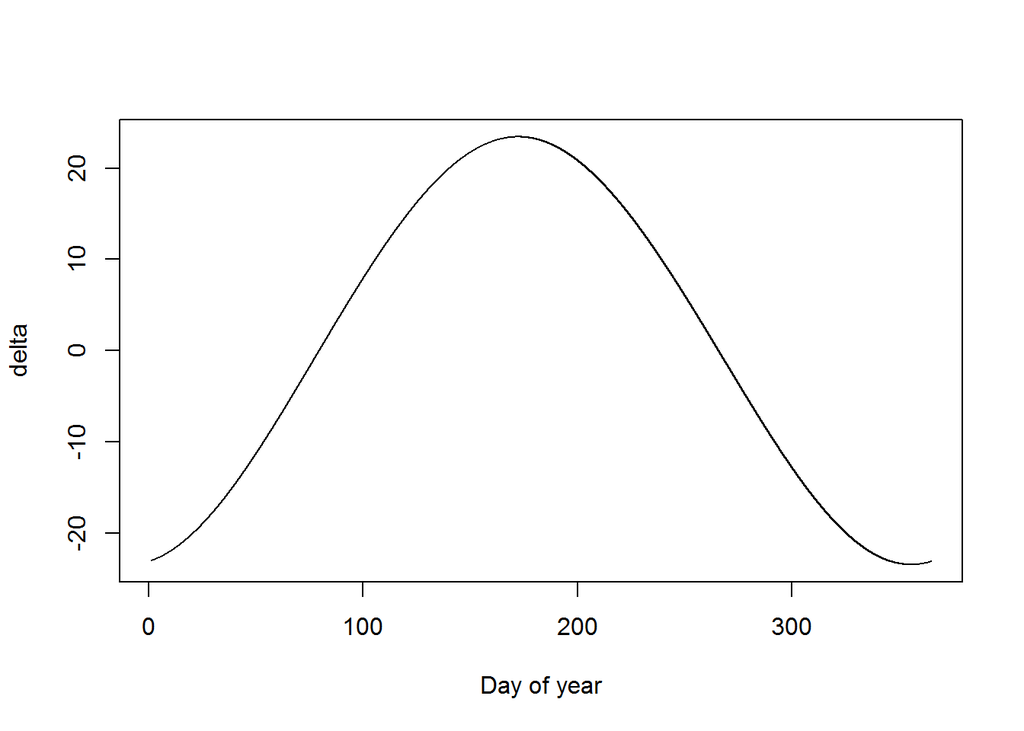

```r
phi=(pi/180)*50
t=seq(1,365,length.out=365*288)
plot(t,180*deltaOdot(t)/pi,typ="l",ylab="delta",xlab="Day of year")
```

#### Length of day

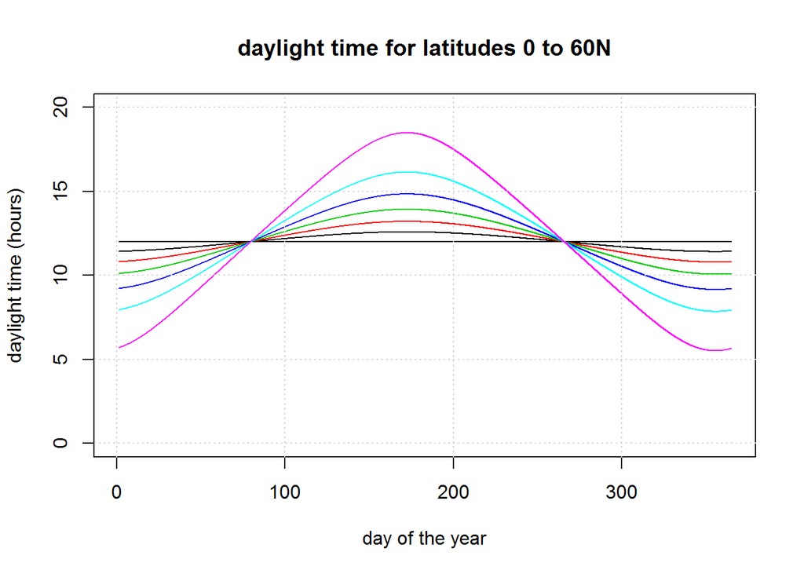

```r
t=seq(1,365,length.out=360*288)
phi=(pi/180)*0.01
h0s<-h0(phi,t)
plot(t,24*(pi-h0s)/pi,type="l",ylim=c(0,20),xlab=("day of the year"),ylab=("daylight time (hours)"),
     main=("daylight time for latitudes 0 to 60N"))
for (lat in seq(10,60,10)){
  phi=(pi/180)*lat
  h0s<-h0(phi,t)
  lines(t,24*(pi-h0s)/pi,type="l",col=lat/10)
}
grid(col = "lightgray", lty = "dotted",
     lwd = par("lwd"), equilogs = TRUE)
```

#### insolation during one day

```r
#choose the day
day<-0
# choose the latitude
phi=(pi/180)*50
S0=1000

t=seq(1,366,length.out=365*144)
t10min<-seq(1,52560)
daybegin<-1
dayend<-365*144
Q<-solarFlux(S0,phi,t)

clearSkyYear<-data.frame(t10min,Q)
write.table(clearSkyYear,file="clearSkyYear.csv",row.names=FALSE,col.names=FALSE,sep=",")
```

#### Comparison with Duchy data

```r
csk<-read.csv("clearSkyYear.csv",stringsAsFactors=FALSE,header=FALSE)
duchy<-read.csv("duchy.csv",stringsAsFactors=FALSE,header=FALSE)
names(csk)=c("t10min","Sol")
names(duchy)=c("t10min","Sol")
```

```r
csk$day=csk$t10min %/% 144 +1
csk$day[52560]=365
duchy$day=duchy$t10min %/% 144 +1
```

```
## [1] "288 144 144"
```

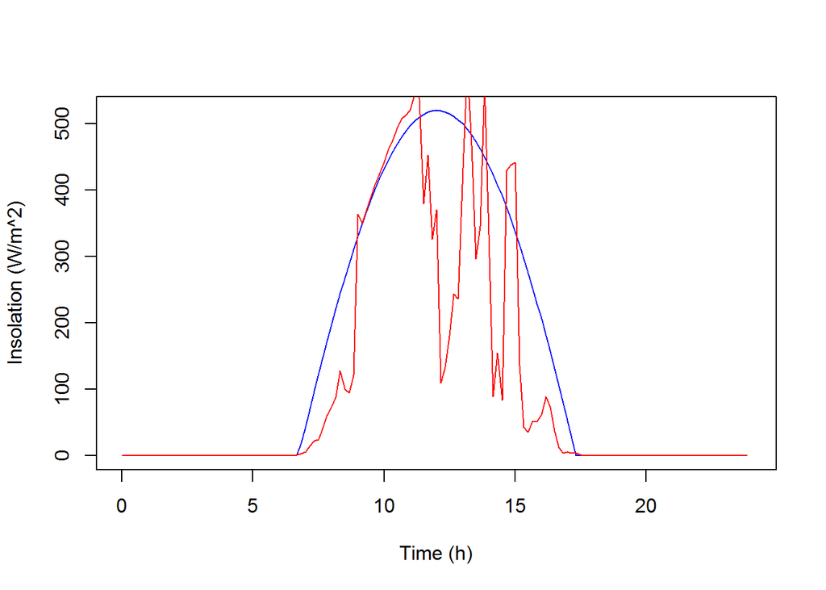

```
## [1] "289 144 144"
```

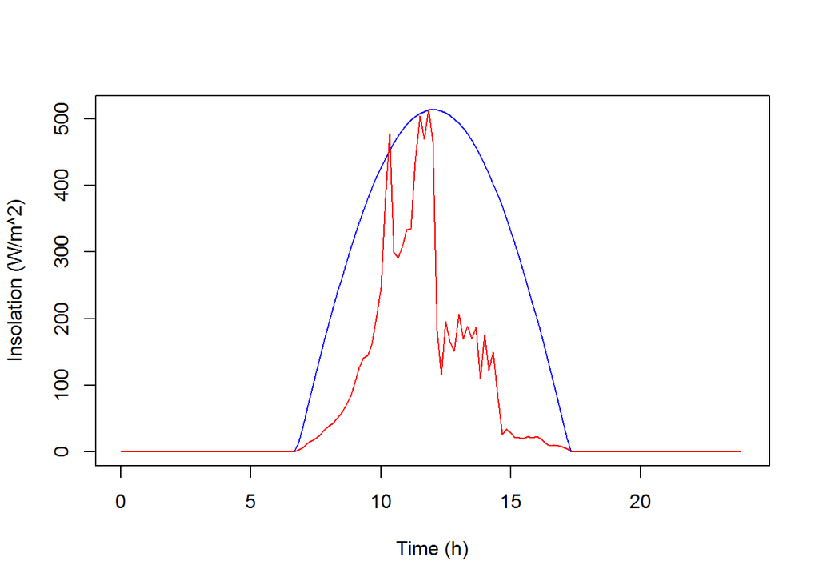

```
## [1] "290 144 144"
```

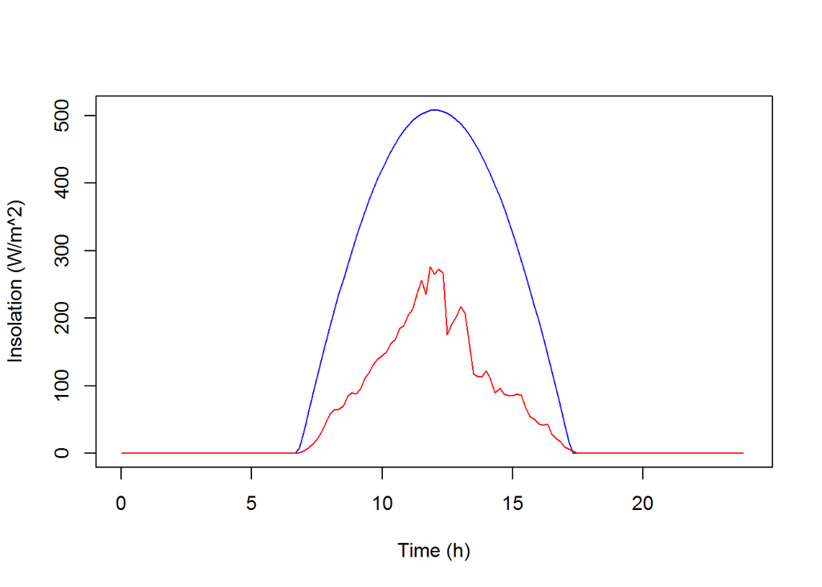

```
## [1] "291 144 144"
```

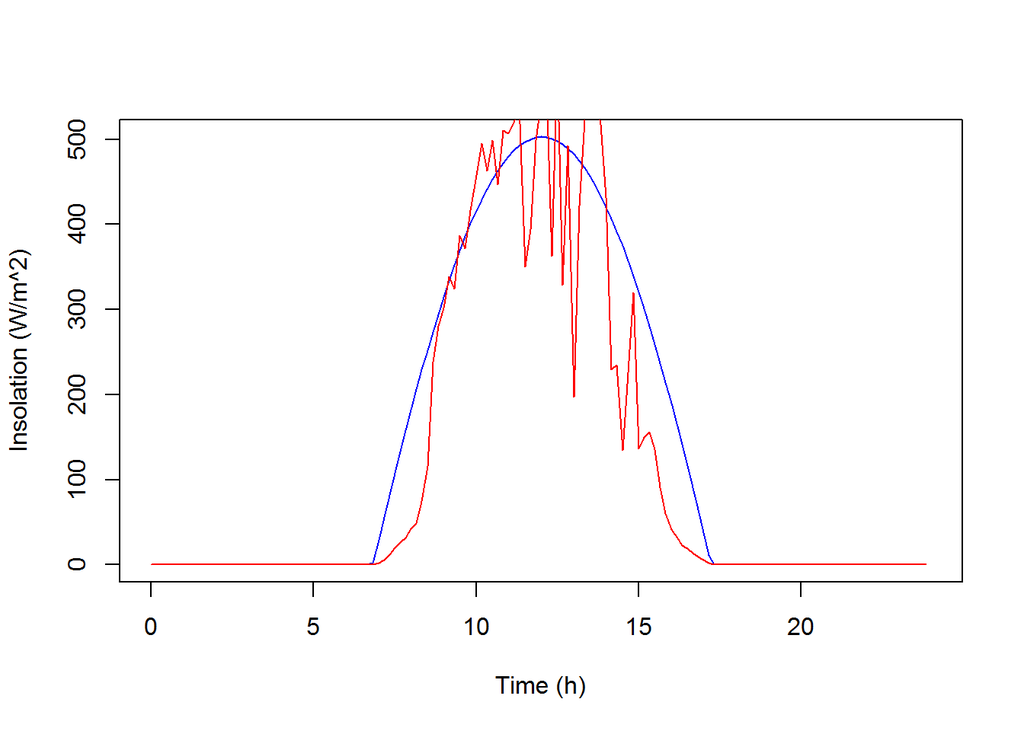

```
## [1] "292 144 144"
```

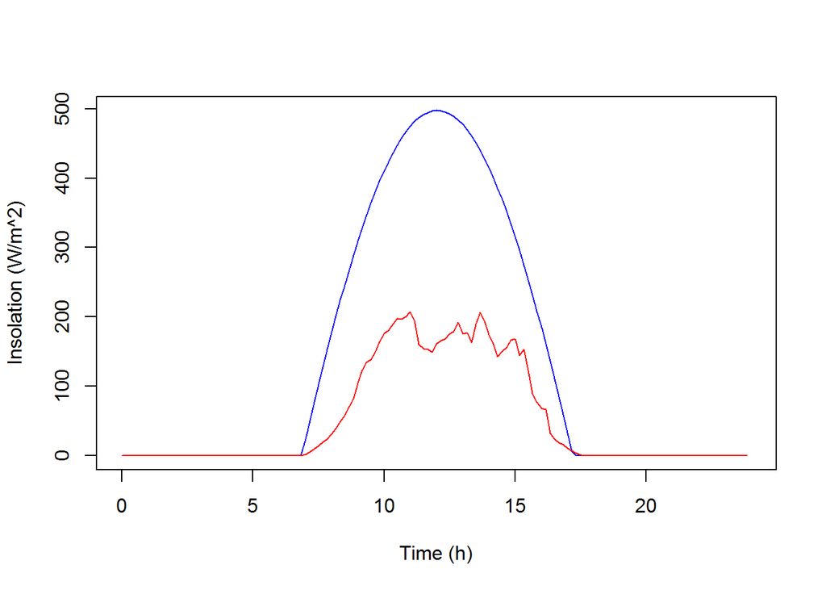

```
## [1] "293 144 144"
```

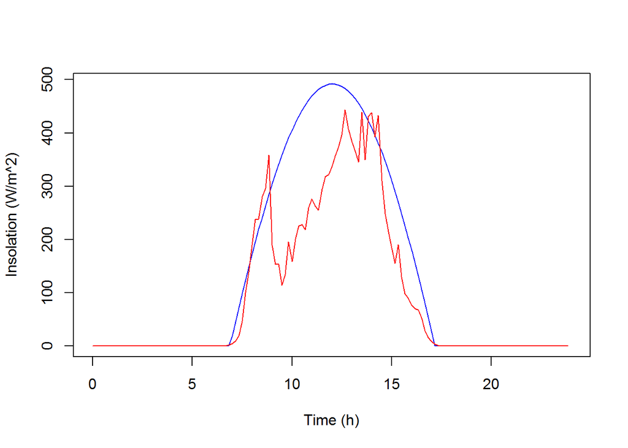

```
## [1] "294 144 144"
```

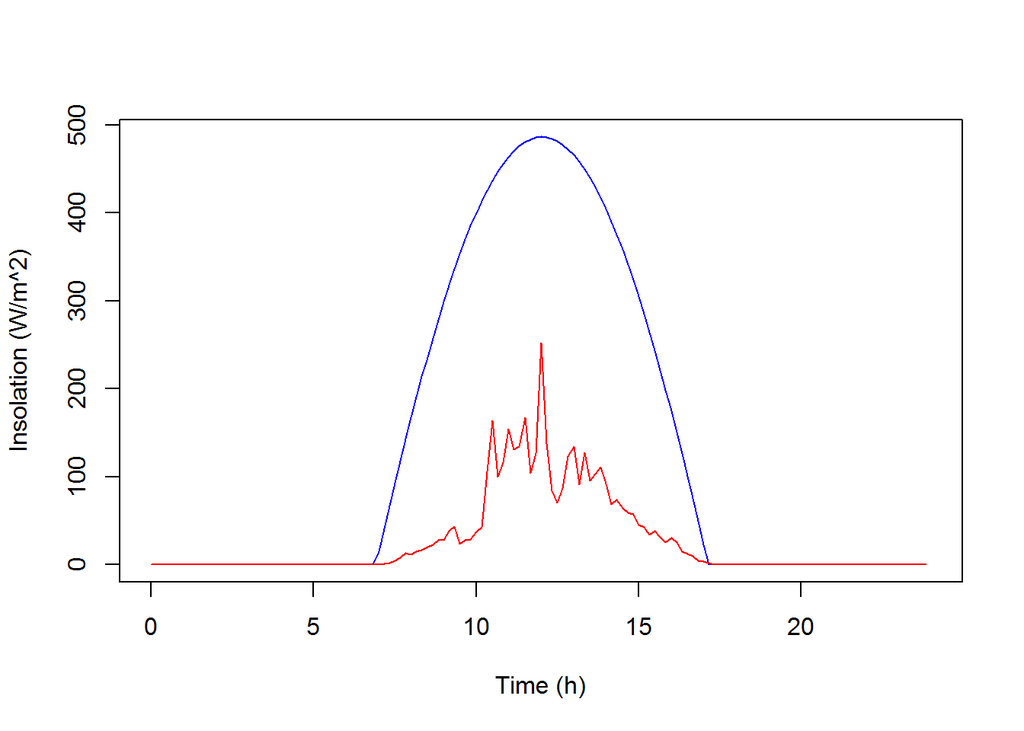

```
## [1] "295 144 144"
```

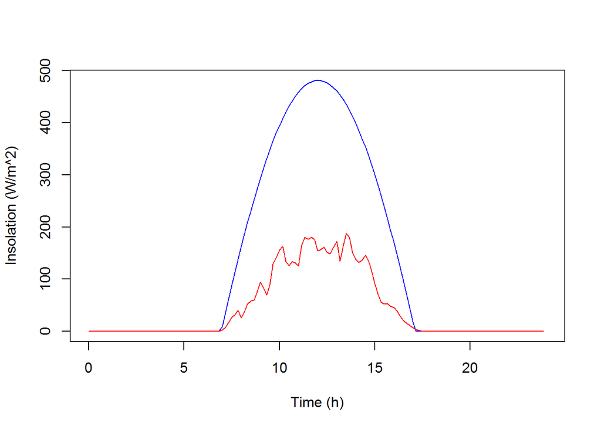

```
## [1] "296 144 144"
```

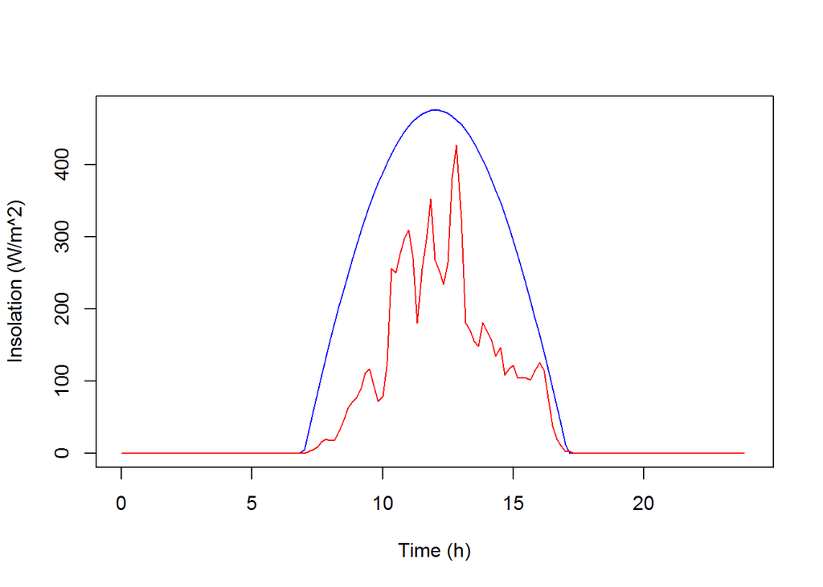

```
## [1] "297 144 144"
```

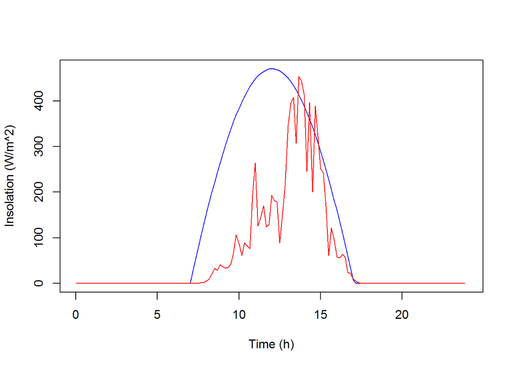

```
## [1] "298 144 144"
```

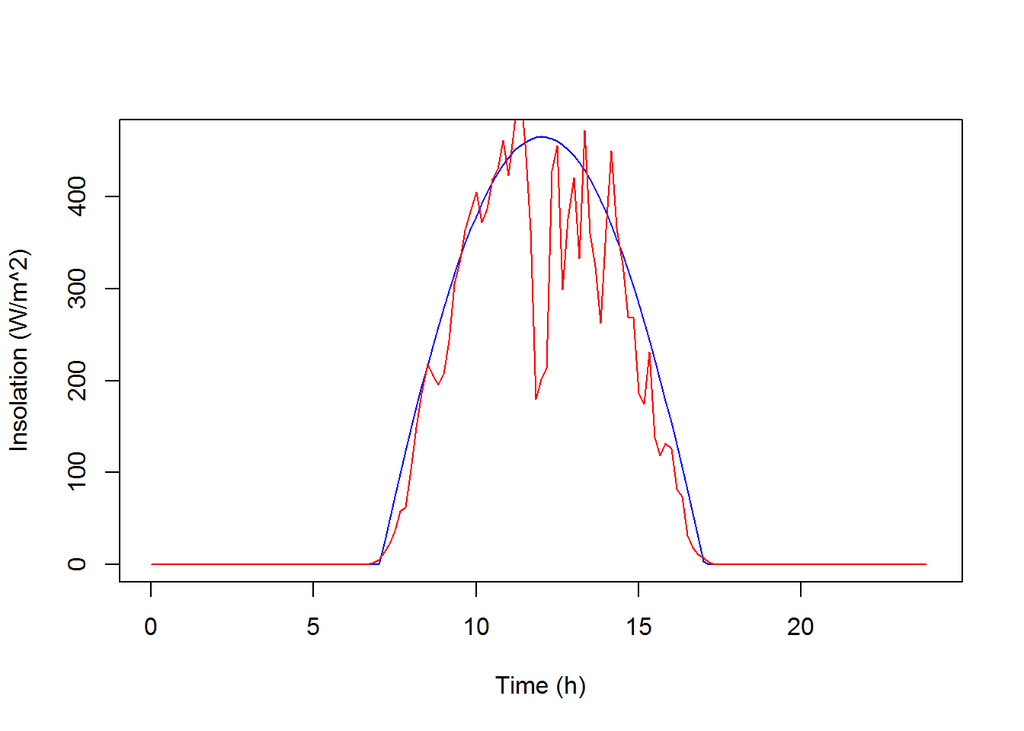

```
## [1] "299 144 144"
```

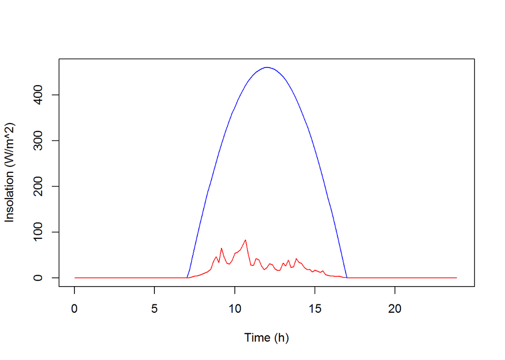

```
## [1] "300 144 144"
```

[65 more figures not shown]

```r
day=2
hours=seq(0,143)/6

for (day in 288:364){

thisday=cbind(hours,csk[csk$day==day,2],duchy[duchy$day==day,2])
print (paste(day,length(thisday[,2]),length(thisday[,3])),sep=",")
plot(hours,thisday[,2],xlim=c(0,24),xlab="Time (h)",ylab="Insolation (W/m^2)",col="blue",type="l")
lines(hours,thisday[,3],col="red")
}
```

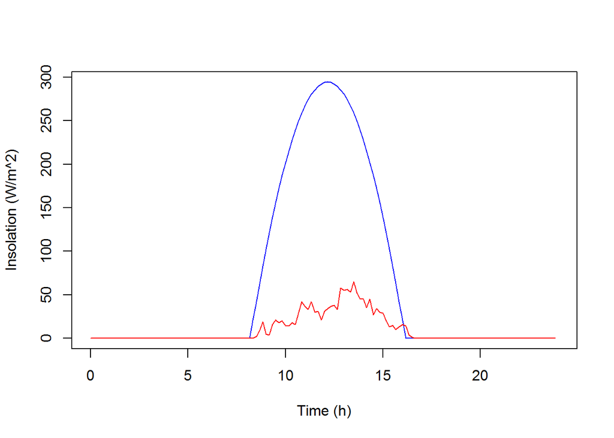

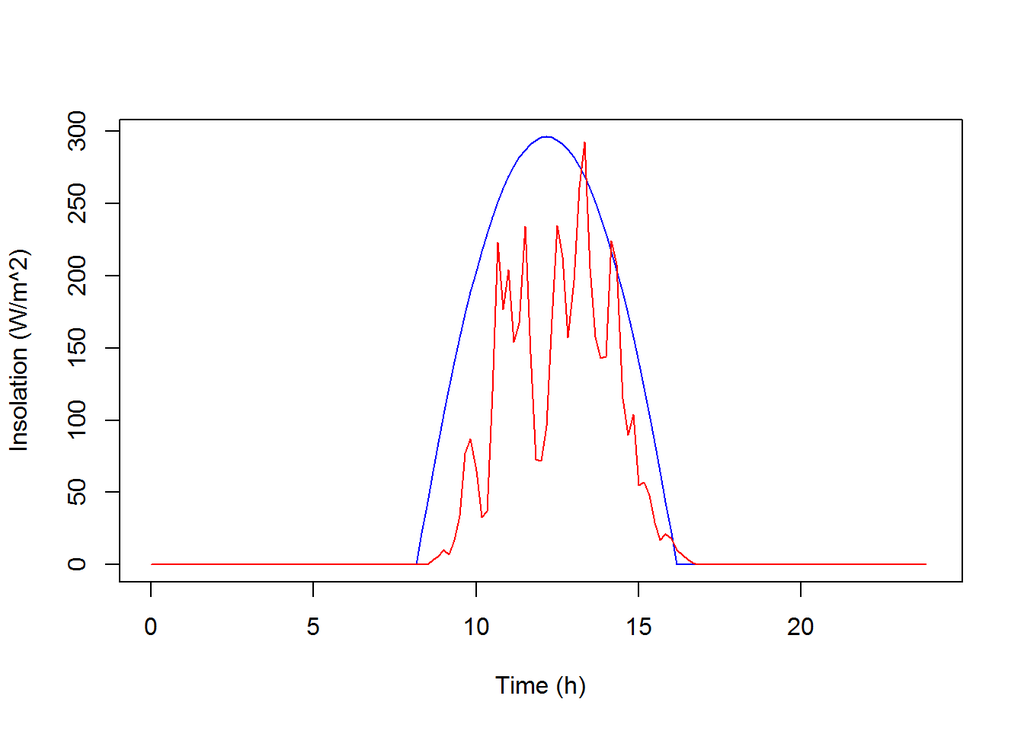

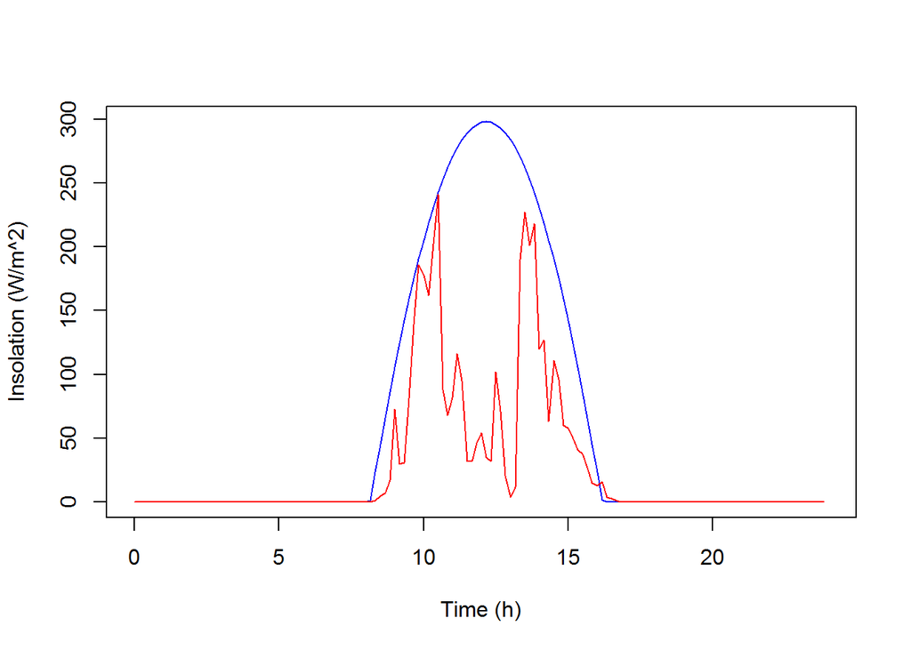

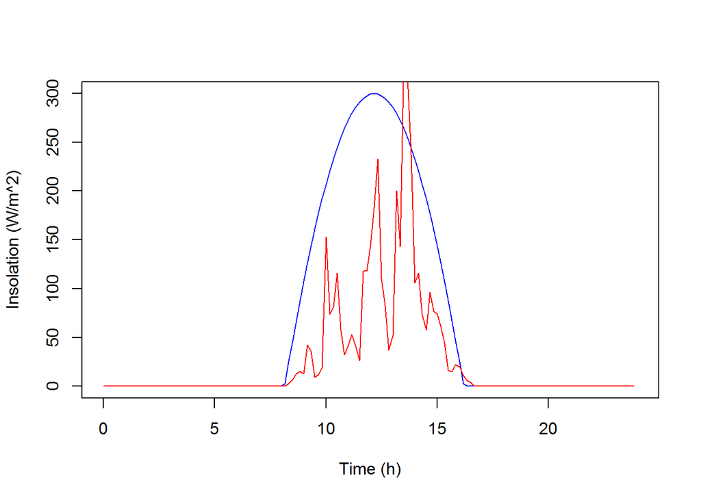

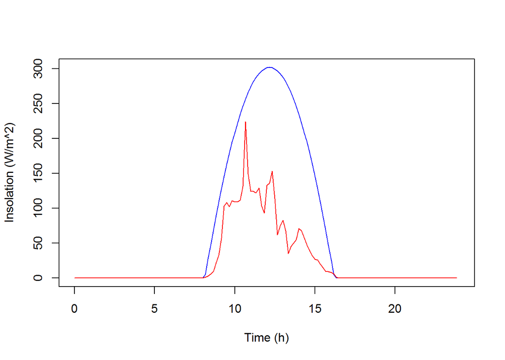

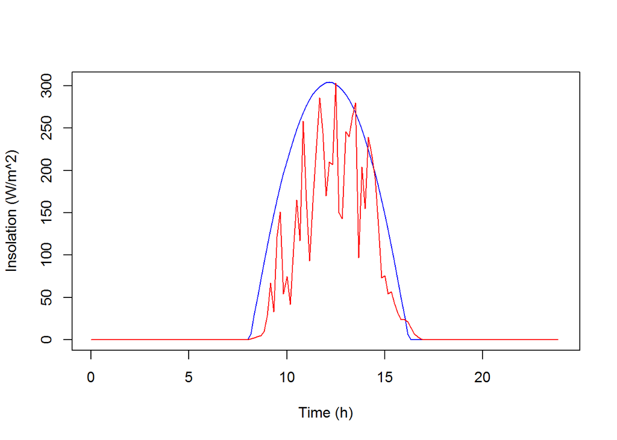

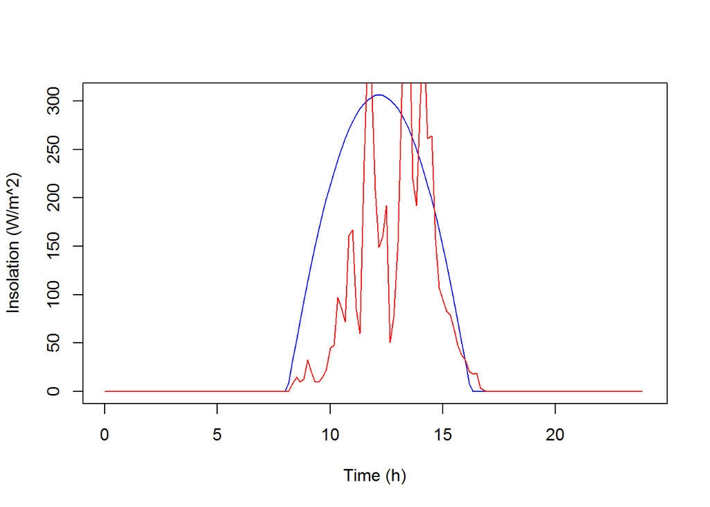

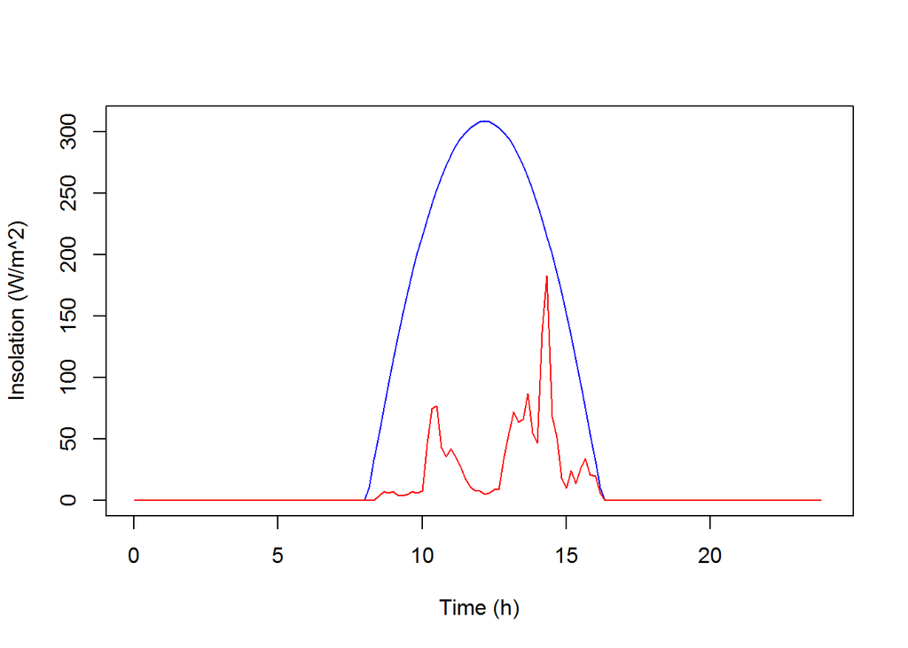

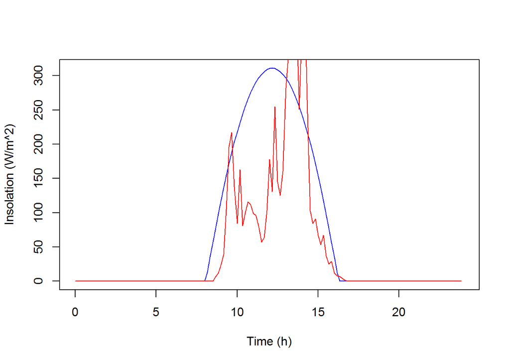

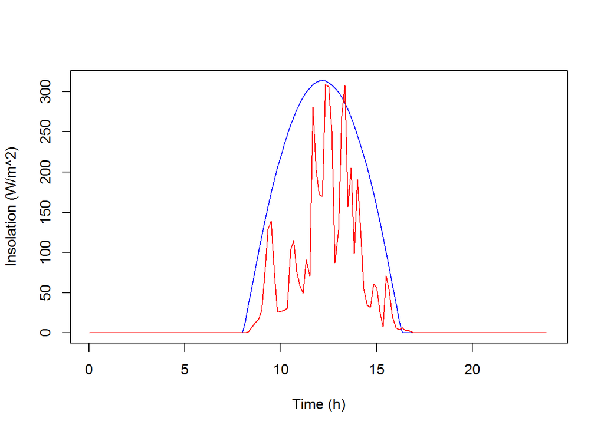

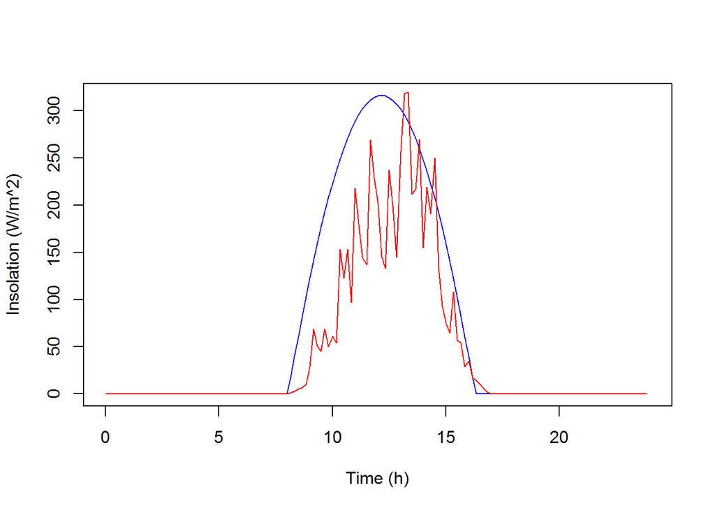

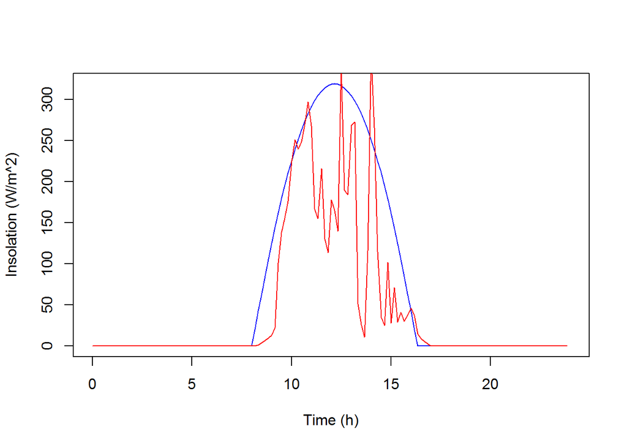

[92 more figures not shown]

```r
for (day in 2:105){
thisday=cbind(hours,csk[csk$day==day,2],duchy[duchy$day==day,2])
plot(hours,thisday[,2],xlim=c(0,24),xlab="Time (h)",ylab="Insolation (W/m^2)",col="blue",type="l")
lines(hours,thisday[,3],col="red")
}
```